# Wearable Analysis

Dennis Wandschura

2025-07-12

## Summary

In this report i build a random forest model with data from wearable sensors, which were worn by users during exercise. The goal was to predict the exercise quality based on the gathered data.

Building two random forest models, one with only the accelerometer data as predictors, both were able to predict 100% of the training data. The out of sample error should be quite low with both models.

The predictions for the testing data differed only in one case.

## Data Exploration

Loading the data there are 19622 rows and 160 columns in the training data.

```r
testingOriginal <- vroom("./data/pml-testing.csv", delim = ",", show_col_types = FALSE)
trainingOriginal <- vroom("./data/pml-training.csv", delim = ",", show_col_types = FALSE)
dim(trainingOriginal)
```

```
## [1] 19622   160
```

Because we will be using the data of the accelerometers on the belt, forearm, arm, and dumbell i am removing the unused columns. One set of data uses only the accelerometer data, the other also includes the other data.

```r
columnsToUse <- apply(testingOriginal, 2, function(x) !any(is.na(x)))
training <- trainingOriginal[, columnsToUse] %>% as_tibble
testing <- testingOriginal[, columnsToUse] %>% as_tibble

accelColums <- grep("accel", names(testing))
trainingColumns = c(8:ncol(training))

trainingAccel <- training[,accelColums]
trainingAccel$classe = training$classe
testingAccel <- testing[,accelColums]

training <- training[,trainingColumns]
testing <- testing[,trainingColumns]
```

## Building the model

Visualizing the correlation matrix. Most variables have a low correlation but it might be a good idea to remove the *total_accel* variables

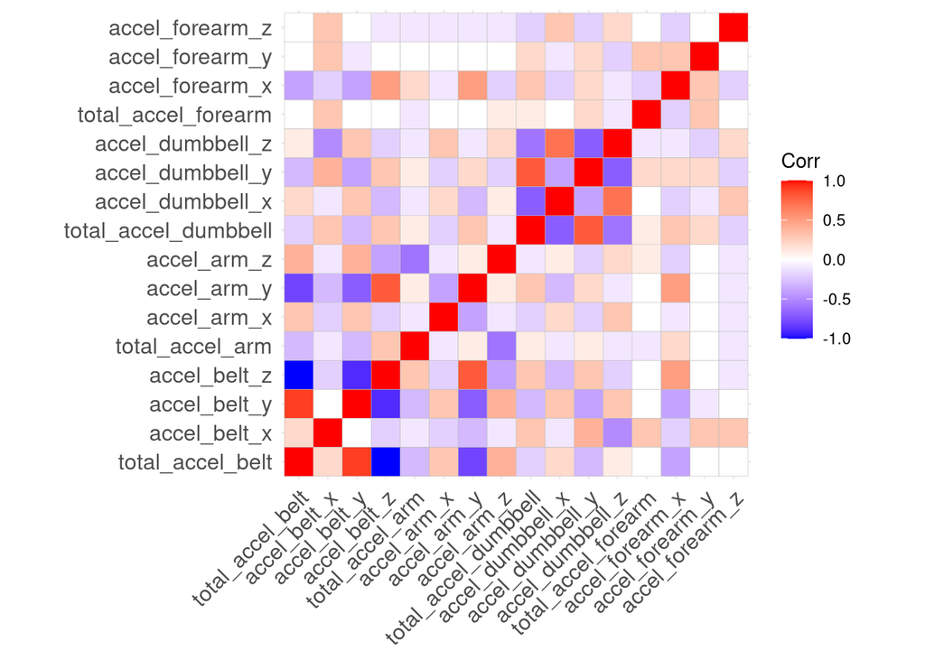

```r
ggcorrplot(round(cor(trainingAccel[,-17]), 1))
```

Removing the *total* columns, because they have a high correlation within their group.

```r
columnsTotalAccel <- grep("total", names(trainingAccel))
trainingAccel <- trainingAccel[,-columnsTotalAccel]
testingAccel <- testingAccel[,-columnsTotalAccel]

columnsTotalAll <- grep("total", names(training))
training <- training[,-columnsTotalAll]
testing <- testing[,-columnsTotalAll]
```

I am building two random forest models with cross validation, one with only the accelerometer data as predictors and one using all predictors. The random forest model is a top performing model, which is why i chose to use it. I also use cross validation with the parameters used in the lecture to get improved accuracy for the models

```r
trControl<- trainControl(method="cv", number=3)

modelRfAccel <- train(classe ~., method="rf", data=trainingAccel, trControl = trControl)

modelRfAll <- train(classe ~., method="rf", data=training, trControl = trControl)
```

To get an estimate of how good the models perform i am comparing the predictions of the training data with the training data results.

```r
predictedRfAccel <- predict(modelRfAccel, trainingAccel)
predictedRfAll <- predict(modelRfAll, training)

# RF with accel data
round(sum(predictedRfAccel == trainingAccel$classe) / nrow(trainingAccel) * 100.0,2)
```

```
## [1] 100
```

```r
# RF
round(sum(predictedRfAll == training$classe) / nrow(training) * 100.0,2)
```

```
## [1] 100
```

Both explain 100% of the training data.

Comparing the prediction of both RF-models on the testing data, they differ in only one case.

```r
predictedAccel <- predict(modelRfAccel, testingAccel)
predictedAll <- predict(modelRfAll, testing)

sum(predictedAccel == predictedAll)
```

```
## [1] 19
```

Usually it is better to include more predictors than less, so i will be using the prediction data from my complete model as my final answer.

```r
predictedAll
```

```
##  [1] B A B A A E D B A A B C B A E E A B B B
## Levels: A B C D E
```